# question1

July 8, 2019

本文分别用Fit-Hi-C和HiCCUPS确定每个样本中可能存在的染色质相互作用，同时找到样本特异的互作并比较两款软件结果的overlap情况

#### Fit-Hi-C

1. **将HiC-Pro的结果转换成Fit-Hi-C需要的输入文件:**

`python /lustre/user/liclab/pengt/projects/tools/HiC-Pro/bin/utils/hicpro2fithic.py -i 5534N_40000.matrix -b`  
`5534N_40000_abs.bed -s 5534N_40000_iced.matrix.biases -r 40000 -o ./5534N/resolution_40k/ &`

2. **运行Fit-Hi-C:**

`python /lustre/user/liclab/pengt/projects/tools/fithic/fithic/fithic.py -i fithic.interactionCounts.gz`  
`-f fithic.fragmentMappability.gz -t fithic.biases.gz -r 40000 -L 1 -o ./`

3. **获得统计显著的互作，阈值为FDR<0.01:**

`python /lustre/user/liclab/pengt/projects/lung/hicpro/5534N/resolution_40k/get_sig.py`

#### HiCCUPS

1. **从HiC-Pro结果的allvalidpairs文件中取出需要的列：**

`awk '{$4=$4!="+"; $7=$7!="+"; split($9, frag1, "_"); split($10, frag2, "_"); } $2<=$5{print $1, $4, $2, $3,`

`'frag1[3], $7, $5, $6, frag2[3], $11, $12 }$5<$2{ print $1, $7, $5, $6, frag2[3], $4, $2, $3, frag1[3], $12, $11}'`

`/lustre/user/liclab/lirf/Project/hic/bgi/lung-work/lung-hic/6405T/hicpro_result/hic_results/data/5534N/5534N_allValidPairs`

`> 5534N_allValidPairs &`

2. **取出cis互作的reads pair：**

`python cis.py`

3. **排序：**

`sort -k3,3d -k7,7d 5534N_pair > 5534N_sorted_pair &`

4. **获得HiCCUPS需要的.hic文件:**

`java -Xmx6g -jar /lustre/user/liclab/pengt/projects/tools/juicer/CPU/common/juicer_tools.jar pre -r 40000`  
`5534N_sorted_pair 5534N.hic hg19 &`

5. **运行HiCCUPS:**

`/lustre/user/liclab/pengt/projects/tools/juicer/CPU/common/juicer_tools hiccups --cpu -m 512 -r 4000 -f .1 -p 1 -i 3`  
`-t 0.02,1.5,1.75,2 -d 80000 &`

#### Compare

1. **确定每种工具结果中染色质互作的重叠情况:**

`bedtools pairtopair -slop 20000 -a 5534N -b 5534T_6 > 5534NT`

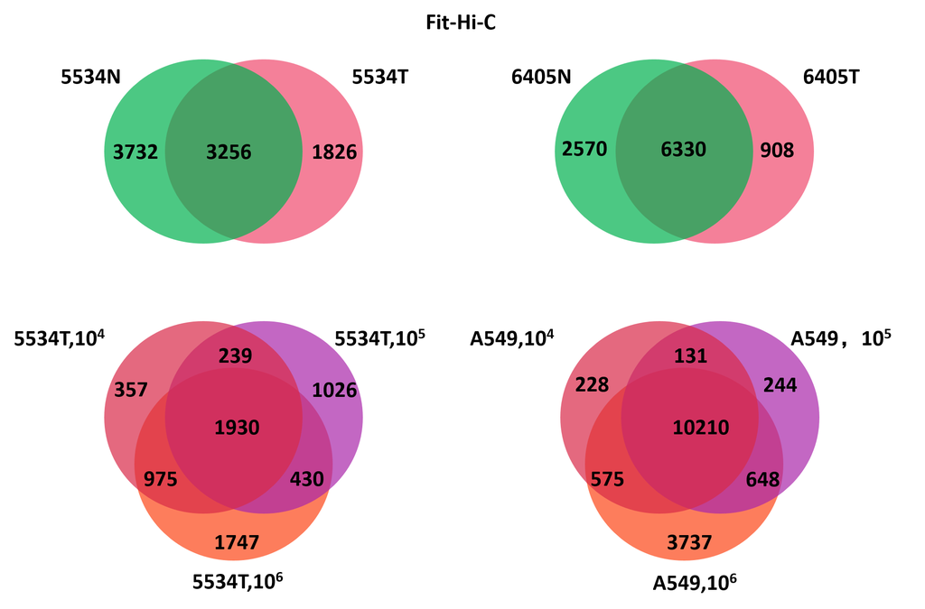

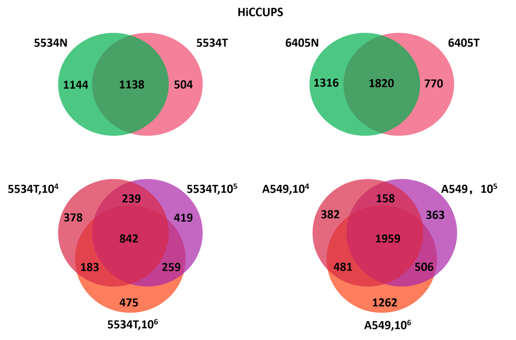

2. **每个样本两款工具的结果取交集结果统计：**

```r
data = read.csv('intersect_result.csv',header = T)
data
```

```
##        Sample FitHiC HiCCUPS Only_in_FitHiC Only_in_HiCCUPS Both
## 1       5534N   6988    2282           5693             987 1295
## 2  5534T_10_4   3501    1642           2760             901  741
## 3  5534T_10_5   3625    1759           2691             825  934
## 4  5534T_10_6   5082    1759           4262             939  820
## 5       6405N   8900    3136           6891            1127 2009
## 6       6405T   7238    2590           5616             968 1622
## 7   A549_10_4  11144    2980           9249            1085 1895
## 8   A549_10_5  11233    2986           9349            1102 1884
## 9   A549_10_6  15170    4208          12520            1558 2650
## 10  GM12878_1  16933    3637          15553            2257 1380
## 11  GM12878_2  16289    2099          15521            1331  768
## 12  GM12878_3  17270    2810          16230            1770 1040
```

#### APA分析

1. **利用juicertools的apa工具评估static，normal-specific，tumor-specific loops在样本中的富集程度：**

`/lustre/user/liclab/pengt/projects/tools/juicer/CPU/common/juicer_toos apa --cpu -r`  
`4000 -n 30 -w 5 -u ./6405N/juicer/6405N_40.hic T_uniq ./6405diff/N_Tuniq`

2. **结果：**

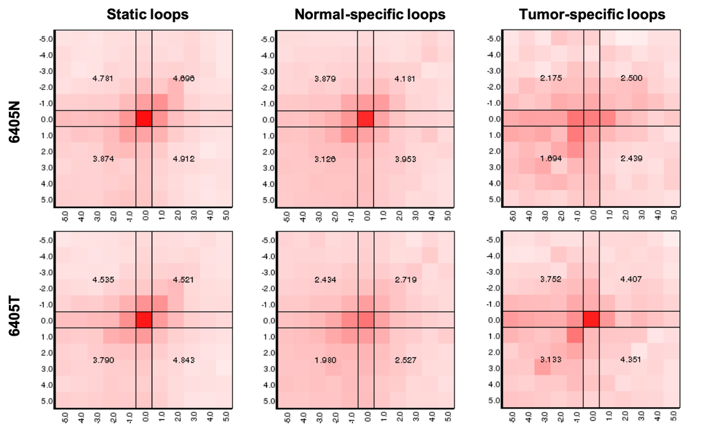